# HW8

Bertrand Black

4/15/2021

### Introduction

For this exercise, I chose to use a data set from Alves et al (2010). This study investigated the forest structure and above ground biomass of three categories of canopy dwelling vascular plants (hardwood trees, palms, and tree ferns) from the unique Atlantic forest bioregion near the coast of southern Brazil. In my line of research (fern biogeography and biodiversity), a clear pattern has emerged where we see the highest amount of fern species richness restricted to the mid-elevations on mountains in the tropics. With this in mind, I wanted to use the Alves et al (2010) tree fern data to test the hypothesis that we will see the same pattern reflected for above ground biomass at mid-elevations in the Atlantic forests of Brazil. More specifically, I predict that the as elevation increased so does tree fern biomass.

### Random data set generation

To test that hypothesis that tree fern biomass increased with elevation, I will first create a data frame for the data and then generate random data using the same samples sizes, means, and variance from the Alves et al (2010) study.

#### Data frame creation

```r
tf_data=data.frame(
  plot=rep(1:12, times=1),
  elevation= 0,
  biomass=0)

print(tf_data)
```

```
##    plot elevation biomass
## 1     1         0       0
## 2     2         0       0
## 3     3         0       0
## 4     4         0       0
## 5     5         0       0
## 6     6         0       0
## 7     7         0       0
## 8     8         0       0
## 9     9         0       0
## 10   10         0       0
## 11   11         0       0
## 12   12         0       0
```

#### Random data set input for tree fern elevational zones.

```r
tf_data[1:12, "elevation"] = abs(rnorm(n= nrow(tf_data), mean = 462.33 , sd = 425.74))

print(tf_data)
```

```
##    plot   elevation biomass
## 1     1  217.638972       0
## 2     2 1324.124606       0
## 3     3  117.350984       0
## 4     4    8.541333       0
## 5     5  741.038189       0
## 6     6  137.700478       0
## 7     7  285.242990       0
## 8     8  490.757815       0
## 9     9  260.242494       0
## 10   10 1186.271333       0
## 11   11  516.377572       0
## 12   12  550.858465       0
```

#### Random data set input for tree fern biomass.

For the purposes of this exercise, the mean and standard deviation for the above ground biomass (Mg ha^-1) was used. The absolute value of the random normal number function was used in order to only generate positive biomass data, as would be expected from this study. This will allow us to compare to continuous variables using a regression analysis.

```r
tf_data[1:12, "biomass"] = abs(rnorm(n= nrow(tf_data), mean = 0.22 , sd = 0.27))

print(tf_data)
```

```
##    plot   elevation     biomass
## 1     1  217.638972 0.086325925
## 2     2 1324.124606 0.158163562
## 3     3  117.350984 0.081446666
## 4     4    8.541333 0.050645910
## 5     5  741.038189 0.565052137
## 6     6  137.700478 0.003935199
## 7     7  285.242990 0.009990317
## 8     8  490.757815 0.231435579
## 9     9  260.242494 0.174207834
## 10   10 1186.271333 0.079628361
## 11   11  516.377572 0.354326554
## 12   12  550.858465 0.089094117
```

#### Data Analysis

Now we will analyze the data and see if there is a a significant impact of elevation on tree fern biomass and create a figure illustrating the results.

```r
library(ggplot2)

# model
tf_regModel <- lm(biomass~elevation,data=tf_data)
print(tf_regModel)
```

```
##
## Call:
## lm(formula = biomass ~ elevation, data = tf_data)
##
## Coefficients:
## (Intercept)    elevation
##     0.09867      0.00012
```

```r
# summary of model
summary(tf_regModel)
```

```
##
## Call:
## lm(formula = biomass ~ elevation, data = tf_data)
##
## Residuals:
##      Min       1Q   Median       3Q      Max
## -0.16137 -0.10235 -0.04375  0.05171  0.37747
##
## Coefficients:
##              Estimate Std. Error t value Pr(>|t|)
## (Intercept) 0.0986680  0.0735751   1.341    0.210
## elevation   0.0001200  0.0001169   1.026    0.329
##
## Residual standard error: 0.1617 on 10 degrees of freedom
## Multiple R-squared:  0.09524,    Adjusted R-squared:  0.004762
## F-statistic: 1.053 on 1 and 10 DF,  p-value: 0.3291
```

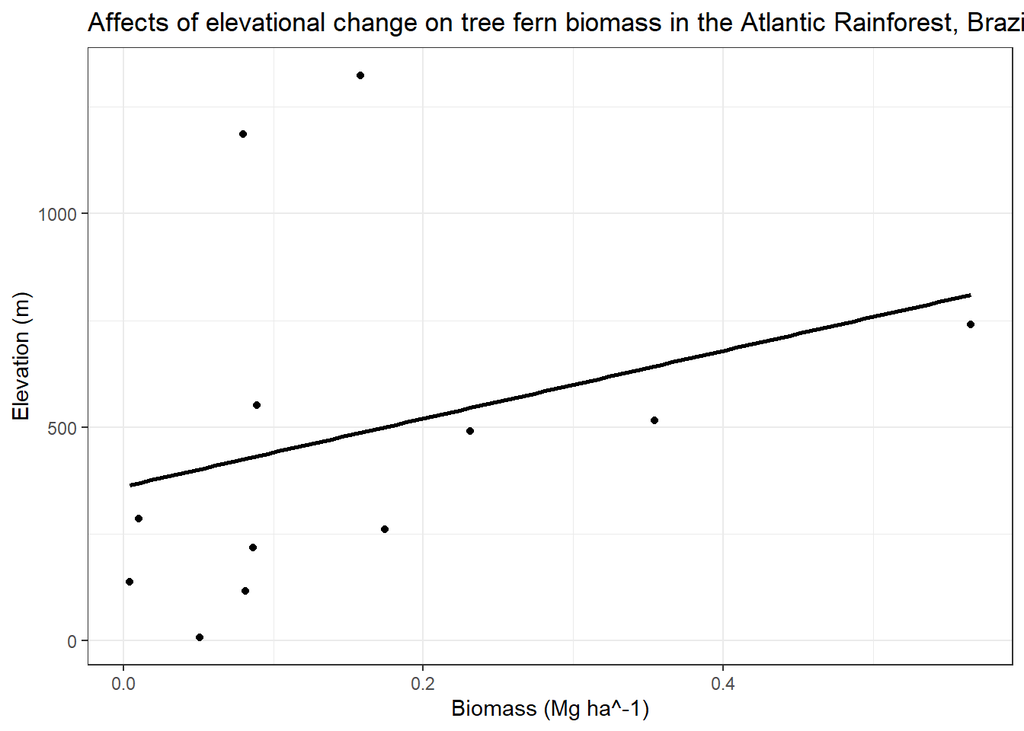

```r
# plot the data
ggplot(tf_data) +
  geom_point(aes(x = biomass, y = elevation)) +
  geom_smooth(aes(x = biomass, y = elevation),
              se = FALSE,
              col = "black",
              method = lm) +
  theme_bw()+
  ggtitle("Affects of elevational change on tree fern biomass in the Atlantic Rainforest, Brazil") +
  ylab("Elevation (m)") +
  xlab("Biomass (Mg ha^-1)")
```

#### Re-run data to see how it changes

```r
tf_data[1:12, "elevation"] = abs(rnorm(n= nrow(tf_data), mean = 462.33 , sd = 425.74))

tf_data[1:12, "biomass"] = abs(rnorm(n= nrow(tf_data), mean = 0.22 , sd = 0.27))

# model
tf_regModel <- lm(biomass~elevation,data=tf_data)
print(tf_regModel)
```

```
##
## Call:
## lm(formula = biomass ~ elevation, data = tf_data)
##
## Coefficients:
## (Intercept)    elevation
##   0.2944533   -0.0001128
```

```r
# summary of model
summary(tf_regModel)
```

```
##
## Call:
## lm(formula = biomass ~ elevation, data = tf_data)
##
## Residuals:
##      Min       1Q   Median       3Q      Max
## -0.17783 -0.11922 -0.01608  0.08953  0.21751
##
## Coefficients:
##               Estimate Std. Error t value Pr(>|t|)
## (Intercept)  0.2944533  0.0755017   3.900  0.00296 **
## elevation   -0.0001128  0.0001372  -0.822  0.43018
## ---
## Signif. codes:  0 '***' 0.001 '**' 0.01 '*' 0.05 '.' 0.1 ' ' 1
##
## Residual standard error: 0.1429 on 10 degrees of freedom
## Multiple R-squared:  0.06331,    Adjusted R-squared:  -0.03036
## F-statistic: 0.6759 on 1 and 10 DF,  p-value: 0.4302
```

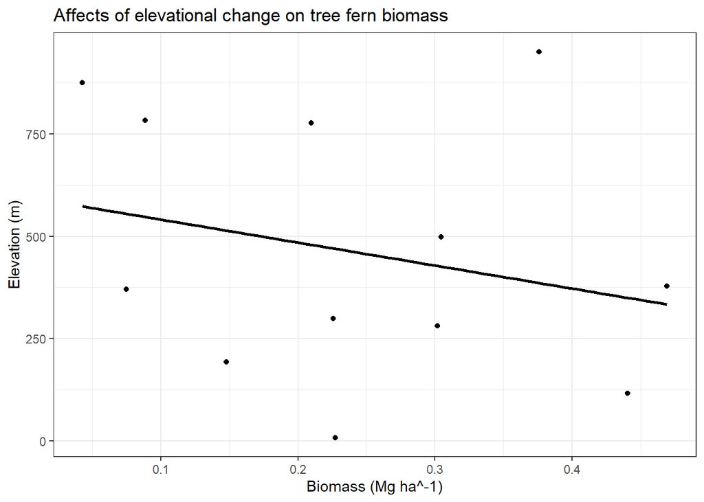

```r
# plot the data
ggplot(tf_data) +
  geom_point(aes(x = biomass, y = elevation)) +
  geom_smooth(aes(x = biomass, y = elevation),
              se = FALSE,
              col = "black",
              method = lm) +
  theme_bw()+
  ggtitle("Affects of elevational change on tree fern biomass") +
  ylab("Elevation (m)") +
  xlab("Biomass (Mg ha^-1)")
```

After re-running the data more than 10 times, the relationship between biomass and elevation was at time significant and at times not significant. I was not surprised by this as I though with such a small sample size (n=12) that there would not be a strong enough interaction in order to be constantly significant when using random positive numbers. The plots continue to show us negative relationships with biomass and elevation but also showed a positive slope in some of the tests, where increases in elevation lead to an increase in tree fern biomass.

#### Limits of the data: mean and sample size

##### After looking at the initial results of the data, I will now adjust the mean and sample size to see how it affects my results.

##### Variation of the means

```r
# Means 50% reduced
tf_data2=data.frame(
  plot=rep(1:12, times=1),
  elevation= 0,
  biomass=0)

tf_data2[1:12, "elevation"] = abs(rnorm(n= nrow(tf_data2), mean = 231.165 , sd = 425.74))

tf_data2[1:12, "biomass"] = abs(rnorm(n= nrow(tf_data2), mean = 0.11 , sd = 0.27))

tf_regModel2 <- lm(biomass~elevation,data=tf_data2)
print(tf_regModel2)
```

```
##
## Call:
## lm(formula = biomass ~ elevation, data = tf_data2)
##
## Coefficients:
## (Intercept)    elevation
##   2.228e-01    3.194e-05
```

```r
summary(tf_regModel2)
```

```
##
## Call:
## lm(formula = biomass ~ elevation, data = tf_data2)
##
## Residuals:
##       Min        1Q    Median        3Q       Max
## -0.177169 -0.149384  0.001325  0.109046  0.298418
##
## Coefficients:
##              Estimate Std. Error t value Pr(>|t|)
## (Intercept) 2.228e-01  8.075e-02   2.759   0.0202 *
## elevation   3.194e-05  1.527e-04   0.209   0.8385
## ---
## Signif. codes:  0 '***' 0.001 '**' 0.01 '*' 0.05 '.' 0.1 ' ' 1
##
## Residual standard error: 0.1629 on 10 degrees of freedom
## Multiple R-squared:  0.004355,   Adjusted R-squared:  -0.09521
## F-statistic: 0.04374 on 1 and 10 DF,  p-value: 0.8385
```

```r
# Means 90% reduced
tf_data3=data.frame(
  plot=rep(1:12, times=1),
  elevation= 0,
  biomass=0)

tf_data3[1:12, "elevation"] = abs(rnorm(n= nrow(tf_data3), mean = 46.233, sd = 425.74))

tf_data3[1:12, "biomass"] = abs(rnorm(n= nrow(tf_data3), mean = 0.022, sd = 0.27))

tf_regModel3 <- lm(biomass~elevation,data=tf_data3)
print(tf_regModel3)
```

```
##
## Call:
## lm(formula = biomass ~ elevation, data = tf_data3)
##
## Coefficients:
## (Intercept)    elevation
##   2.465e-01   -5.693e-05
```

```r
summary(tf_regModel3)
```

```
##
## Call:
## lm(formula = biomass ~ elevation, data = tf_data3)
##
## Residuals:
##      Min       1Q   Median       3Q      Max
## -0.21017 -0.15193  0.05407  0.10553  0.17615
##
## Coefficients:
##               Estimate Std. Error t value Pr(>|t|)
## (Intercept)  2.465e-01  6.625e-02   3.721  0.00397 **
## elevation   -5.693e-05  1.634e-04  -0.348  0.73471
## ---
## Signif. codes:  0 '***' 0.001 '**' 0.01 '*' 0.05 '.' 0.1 ' ' 1
##
## Residual standard error: 0.1511 on 10 degrees of freedom
## Multiple R-squared:  0.012,  Adjusted R-squared:  -0.0868
## F-statistic: 0.1214 on 1 and 10 DF,  p-value: 0.7347
```

Changing the mean did not have so much of an affect on th interaction between tree fern biomass. Both results varied between significant and not significant after a few runs on each.

##### Variation in sample size

```r
# sample size 50% reduced
tf_data4=data.frame(
  plot=rep(1:6, times=1),
  elevation= 0,
  biomass=0)

tf_data4[1:6, "elevation"] = abs(rnorm(n= nrow(tf_data4), mean = 462.33, sd = 425.74))

tf_data4[1:6, "biomass"] = abs(rnorm(n= nrow(tf_data4), mean = 0.22, sd = 0.27))

tf_regModel4 <- lm(biomass~elevation,data=tf_data4)
print(tf_regModel4)
```

```
##
## Call:
## lm(formula = biomass ~ elevation, data = tf_data4)
##
## Coefficients:
## (Intercept)    elevation
##   0.2860775   -0.0001175
```

```r
summary(tf_regModel4)
```

```
##
## Call:
## lm(formula = biomass ~ elevation, data = tf_data4)
##
## Residuals:
##        1        2        3        4        5        6
##  0.15889 -0.08166 -0.01495 -0.11870 -0.15012  0.20655
##
## Coefficients:
##               Estimate Std. Error t value Pr(>|t|)
## (Intercept)  0.2860775  0.1815738   1.576    0.190
## elevation   -0.0001175  0.0003261  -0.360    0.737
##
## Residual standard error: 0.1669 on 4 degrees of freedom
## Multiple R-squared:  0.03143,    Adjusted R-squared:  -0.2107
## F-statistic: 0.1298 on 1 and 4 DF,  p-value: 0.7369
```

```r
# sample size 10 fold increase
tf_data5=data.frame(
  plot=rep(1:120, times=1),
  elevation= 0,
  biomass=0)

tf_data5[1:120, "elevation"] = abs(rnorm(n= nrow(tf_data5), mean = 462.33, sd = 425.74))

tf_data5[1:120, "biomass"] = abs(rnorm(n= nrow(tf_data5), mean = 0.22, sd = 0.27))

tf_regModel5 <- lm(biomass~elevation,data=tf_data5)
print(tf_regModel5)
```

```
##
## Call:
## lm(formula = biomass ~ elevation, data = tf_data5)
##
## Coefficients:
## (Intercept)    elevation
##   2.782e-01    3.252e-05
```

```r
summary(tf_regModel5)
```

```
##
## Call:
## lm(formula = biomass ~ elevation, data = tf_data5)
##
## Residuals:
##      Min       1Q   Median       3Q      Max
## -0.30255 -0.16013 -0.05874  0.09645  0.66950
##
## Coefficients:
##              Estimate Std. Error t value Pr(>|t|)
## (Intercept) 2.782e-01  3.398e-02   8.188 3.56e-13 ***
## elevation   3.252e-05  6.273e-05   0.518    0.605
## ---
## Signif. codes:  0 '***' 0.001 '**' 0.01 '*' 0.05 '.' 0.1 ' ' 1
##
## Residual standard error: 0.2106 on 118 degrees of freedom
## Multiple R-squared:  0.002272,   Adjusted R-squared:  -0.006184
## F-statistic: 0.2687 on 1 and 118 DF,  p-value: 0.6052
```